# On the Stability of BOLD fMRI Correlations | Cerebral Cortex | Oxford Academic

### Fluctuating Drowsiness Contributes to Nonconstant RSFC

Sleep changes the correlation structure of spontaneous BOLD fMRI (Picchioni et al. 2013). Moreover, Tagliazucchi and Laufs (2014) have demonstrated that many data sets acquired with the intention of studying the awake resting state are contaminated by sleep. Hence, drowsiness is a likely source of “bona fide” (i.e., of neural origin) nonstationarity in RSFC. Since our data were not acquired with simultaneous EEG recording, we used the Tagliazucchi/Laufs data set (Tagliazucchi et al. 2013), in which sleep stage is known, to define a set of regions by which it is possible to compute a “SI” for each fMRI run. The most discriminating regions for identifying sleep in eyes-closed data are in visual cortex, somatomotor cortex, and the thalamus (Tagliazucchi et al. 2012b). We omitted visual regions in formulating our SI as our data were collected with eyes-open, while Tagliazucchi/Laufs data set was collected with eyes-closed, as these regions are most affected by eye state (McAvoy et al. 2008; Bianciardi et al. 2009). Given that subjects tend to become drowsy over the course of a 30-min resting state fMRI run (even if they are instructed to stay awake and maintain visual fixation), we may expect that the SI should systematically increase with time in the scanner. Supplementary Figure S6 demonstrates that, on average, this effect was observed in our data.

We plotted kurtosis against the SI across sessions, restricting this analysis to frame-censored data. This analysis revealed a significant correlation between the two measures (*r* = 0.315, *p* = 0.0044; Fig. 5). Thus, fluctuating drowsiness over the course of a resting state session may contribute to observed non-normality in RSFC. However, in our data, this effect is quantitatively dwarfed by the effects of head motion (compare scales in Figs 4*A* vs. 5).

Figure 5.

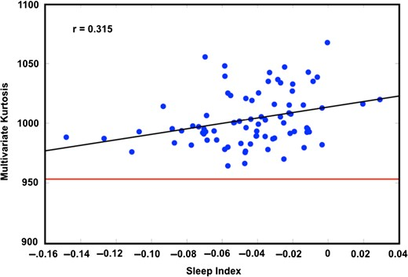

[Open in new tab](https://academic.oup.com/view-large/figure/96463349/bhw265f05.tif)Download slide

Multivariate kurtosis correlates with SI. Kurtosis is computed on the first 30 principal components derived from each session. Sessions have been frame censored. Any session with fewer than 50% frames retained has been removed. One session with a kurtosis measure 4.7 SD from the mean was excluded. The average kurtosis corresponding to simulated stationary data is indicated by the red line (~952).

### Induced Changes in Cognitive State are Detectable Using Multivariate Kurtosis

Figure 6.

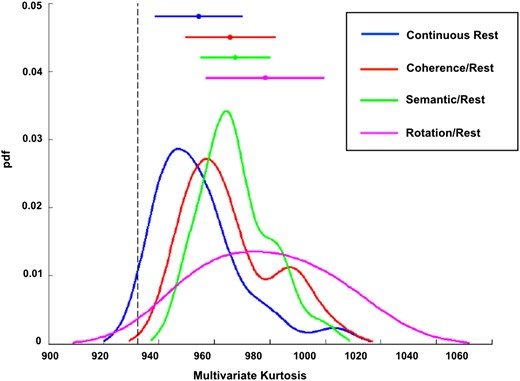

[Open in new tab](https://academic.oup.com/view-large/figure/96463352/bhw265f06.tif)Download slide

Alternating blocks of task/rest give rise to greater multivariate kurtosis than continuous resting state. Kurtosis values from task/rest runs (3 duplicate runs per paradigm) were averaged and compared with kurtosis values from continuous resting state runs of the same length (470 s) in the same subjects (*N* = 24). Three different task paradigms were used: Glass pattern coherence discrimination (red), noun versus verb semantic judgment (green), and mental rotation (purple). Plots represent smoothed histograms of the kurtosis values. Bars above indicate the mean and standard deviation for each condition. The dotted black line represents the mean kurtosis (932) of simulated stationary data of the same length as the task runs. Nonsmoothed histograms are reported in Supplementary Figure S5.

## Discussion

We evaluated the degree to which the correlation structure of BOLD fMRI is stable over time using multivariate kurtosis and comparing real data to statistically matched stationary simulations. In the resting state, we find that observed fluctuations in correlation structure are largely attributable to three major factors: 1) sampling variability intrinsic to measuring correlations in short windows; 2) signal changes related to head motion; and 3) correlation changes related to changes in sleep state. Of these, only the last is physiologically meaningful. Thus, the correlation structure of resting-state BOLD fMRI data appears to be very nearly constant, discounting the effects of sleep and head motion. On the other hand, changes in cognitive state induced by alternating task with rest blocks were associated with increased multivariate kurtosis (Fig. 6).

We should be clear that multivariate kurtosis assesses the degree to which a process is multivariate normal with constant covariance; it does not fully assess the stationarity of all aspects of a process. For example, nonconstant spectral content would not be detectable by kurtosis, provided that the covariance is constant (see Appendix of Supplementary Materials for further discussion of this point). Alternative measures that allow for testing of nonstationarity in higher-order statistics and in spectral content do exist (Last and Shumway 2008; Jentsch and Subba Rao 2015). We evaluated kurtosis because it offers the advantage of more straightforward applicability to multivariate data. Kurtosis is sensitive to nonstationarity of second-order statistics, which is the quantity of interest in RSFC studies. Moreover, multivariate kurtosis evaluates the FC of all pairs of regions at once. Alternative techniques are formulated in terms of single pairs of signals (Zalesky et al. 2014; Hindriks et al. 2016).

### Sampling Error Can Lead to the Appearance of “Dynamic” Functional Connectivity

Using a stationary simulation incorporating the spectral content and covariance structure of real BOLD fMRI data, we demonstrate that sampling variability can contribute to the illusory appearance of discrete functional connectivity “states” (Fig. 2). Several recent papers have pointed out that much of the prior literature on “dynamic” functional connectivity is based on inappropriate analytic techniques (Lindquist et al. 2014; Zalesky et al. 2014; Leonardi and Van De Ville 2015). Our results reinforce this observation and further demonstrate that distinct correlation structures extracted from real data closely resemble the correlation structures in simulated stationary data. These results are consistent with work by Hindriks et al. (2016) that reported no evidence of nonstationarity in resting state BOLD correlations, and similar observations made in relation to EEG data (Hlinka and Hadrava 2015). We have also previously shown that day-to-day variability in the correlation structure of resting state BOLD fMRI data (acquired in a single individual) is almost entirely (>98%) attributable to sampling error, that is, is inversely proportional to the total quantity of analyzed data (Laumann et al. 2015). Thus, the model described in the prior work predicts that low reliability will be the dominant feature of RSFC estimation at very short timescales, purely as a result of sampling error. Indeed, the present findings confirm this expectation.

### Head Motion is a Major Source of Artifactually Elevated Kurtosis

Head motion artifact accounts for much of the excess kurtosis observed in our data (Fig. 4). Head motion has already been identified as a major source of artifact in conventional resting state fMRI (Power et al. 2012; Van Dijk et al. 2012). Our analyses (Fig. 4) show that measured multivariate kurtosis is correlated with the quantity of head motion on a per-fMRI-run basis. Importantly, censoring of high-motion frames (FD > 0.2 mm), as previously described (Power et al. 2014) substantially reduced measured kurtosis, far more than randomly removing frames (Supplementary Fig. S4). In a minority of cases, kurtosis was reduced to levels obtained by analysis of matched simulated data (Fig. 4*A*). However, in most cases, this maneuver did not completely eliminate the effects of head motion. Figure 4*C* suggests that if even stricter movement criteria are used more sessions may approach this baseline. These results imply that a substantial portion of RSFC “dynamics” may be attributable to head motion and suggest that caution must be exercised when interpreting measurements of dynamic RSFC. Indeed, subject by subject and day by day differences in motion may lead to artifactual variability in dynamic RSFC measures (Lindquist et al. 2014), making reliable associations with behavioral measures a serious challenge.

### Fluctuating Drowsiness Increases Multivariate Kurtosis of Resting State BOLD fMRI Data

Sleep unambiguously modifies intrinsic neural activity. Indeed, sleep stages are defined in terms of specific EEG signatures (Dement and Kleitman 1957). More recently, it has been shown that sleep staging also can be computed on the basis of RSFC data (Tagliazucchi et al. 2012a) and, moreover, that about one-third of publicly released RSFC data sets are affected by sleep within the first few minutes of scanning, although this finding was less prominent in data sets acquired with eyes-open fixation, as in the present case (Tagliazucchi and Laufs 2014). Nevertheless, we evaluated sleep as an explanatory factor in our results. Following aggressive frame censoring, measured kurtosis was still significantly correlated with the RSFC-derived SI (Fig. 5). Thus, at least some observed non-normality in RSFC is likely related to fluctuating drowsiness over the course of the scan.

Owing to limitations in the design of our SI (see “Materials and Methods” section), it is likely that the present results underestimate the extent to which sleep accounts for variability in RSFC. Our assessment may also be complicated by head motion in subjects who were struggling to keep their eyes-open and stay awake. Some periods of fluctuating drowsiness probably were discarded by frame censoring, thereby reducing our estimated prevalence of sleep.

### Changes in Cognitive State Increase Multivariate Kurtosis of Resting State BOLD fMRI Data

We found that alternating task and rest blocks lead to a measurable, but modest, increment in kurtosis over the level observed in continuous resting state data (Fig. 6). Previous authors have emphasized that task performance does not greatly perturb the “core” architecture of functional connectivity (Cole et al. 2014; Krienen et al. 2014). Nevertheless, statistically reliable changes in correlation structure have been observed in a variety of task contexts (Cole et al. 2014; Krienen et al. 2014; Gonzalez-Castillo et al. 2015). These changes frequently localize to regions of the brain presumed to be involved in task-specific processing, for example, altered FC in visual regions during a visual attention task (Al-Aidroos et al. 2012). Additionally, it has been proposed that spontaneous activity itself is suppressed by task engagement (He 2013). Our results indicate that there are changes in correlation structure between resting state and goal-directed task states, although we cannot distinguish whether these effects reflect suppressed spontaneous activity or task-induced correlation changes. Moreover, as noted above, elevated kurtosis does not distinguish between nonconstant covariance in an otherwise stationary normal process versus other types of deviation from multivariate normality. However, it seems to us most likely that the effects of alternating task state as well as sleep are reflected primarily as changes in covariance.

Importantly, the resting state condition yielded mean kurtosis measures closer to the stationary null model than any of the task-alternation conditions. This observation suggests that the variability in correlation induced by the changes in cognitive state of the magnitude imposed by standard task paradigms does not occur during resting state BOLD runs.

### BOLD Correlations Considered in Relation to Cognition

The present results also reinforce several previously articulated points concerning the robust character of spontaneous BOLD fMRI fluctuations as viewed from multiple perspectives (Raichle and Snyder 2007): 1) The topography of BOLD fMRI correlations remains largely intact during slow-wave sleep (Samann et al. 2011; Mitra et al. 2015b) and even anesthesia (Mhuircheartaigh et al. 2010; Palanca et al. 2015), conditions under which cognition is presumed to be either absent or greatly attenuated. The relative stability observed under these conditions is likely related to underlying constraints of anatomical connectivity (Honey et al. 2009; Lu et al. 2011; Barttfeld et al. 2015) and ongoing synaptic efficacies. 2) Task paradigms are capable of modifying the correlation structure of spontaneous BOLD signal fluctuations (Fig. 6), but only to a limited extent (Cole et al. 2014; Krienen et al. 2014). 3) Whereas unconstrained cognition might be expected to vary from subject to subject and from scan to scan, RSFC is consistent across subjects at the population level (Damoiseaux et al. 2006) and, within individuals, consistent across sessions (Laumann et al. 2015).

The preceding considerations raise two questions: 1) what physiological processes are predominantly represented in ongoing BOLD fluctuations? and 2) why do these processes exhibit a relatively stable correlation structure over time? To address these questions, we invoke the principle that the brain must allow for adaptive plasticity on the basis of new experiences while simultaneously maintaining its functional architecture over extended spans of time (Turrigiano 2012). Ongoing neural activity has been shown to contribute to the sculpting of functionally appropriate connectivity during development (Penn and Shatz 1999; Kirkby et al. 2013). It is likely that similar processes persist into adulthood (Nahmani and Turrigiano 2014). Hebbian-like mechanisms are believed to underlie experience-dependent synaptic plasticity (Lewis et al. 2009; Schacher and Hu 2014), These mechanisms, in turn, are balanced by homeostatic processes that adjust synaptic weights in the wake of experience-dependent perturbations (Marder and Goaillard 2006; Takesian and Hensch 2013; Vitureira and Goda 2013). Although the recent literature on this topic is largely focused on molecular mechanisms (e.g., receptor trafficking, regulatory proteins, and gene expression) (Malenka and Bear 2004; Kullmann et al. 2012), it is critical to keep in mind that plasticity generally is governed by neural activity and that this activity contributes to ongoing BOLD signal fluctuations. RSFC stability over timescales on the order of minutes follows naturally if ongoing neural activity is determined primarily by the long-term configuration of the brain rather than by recent experience. Thus, patterns of BOLD correlations may both reflect current synaptic relationships as well as serve to maintain them.

### Stable RSFC is Compatible with “Dynamic” BOLD Features and the Possibility that Ongoing BOLD Activity Influences Behavior

It is important to note that a stable correlation structure in resting-state BOLD is compatible with a large repertoire of dynamic behavior and functional associations. For example, Liu and Duyn (2013) have described a “snapshot” phenomenon, that is, brief epochs in which the topography of particular RSNs emerges from the ongoing activity. In a univariate normal process, excursions exceeding ±2 SD may be expected to occur in 5% of samples. A similar principle applies to multivariate normal processes. Thus, the presence of single frame coactivation patterns is not precluded by the results of this work.

Stationarity of BOLD correlation structure also does not preclude the possibility that the instantaneous state of neural activity biases cognitive operations, perceptions, or motor behavior (Hutchison et al. 2013a). Several studies have reported that resting-state BOLD fMRI fluctuations bias perceptions as well as motor behavior (Bishop 1932; Fox et al. 2007; Hesselmann et al. 2008; Sadaghiani et al. 2010). It has been suggested that intrinsic variability (stochastic dynamics) is advantageous because it promotes exploration of the range of responses to a given circumstance (Deco et al. 2009). None of these considerations imply that the second-order statistics of ongoing neural activity necessarily are nonstationary. The aforementioned hypothetical frictionless pendulum again provides a useful analogy. Just as the pendulum might turn on a light at one end of its excursion, a similar process within the brain could influence behavior. Furthermore, just as an applied external force might cause the motion of the pendulum to be nonstationary, environmental events may generate neural responses. Such responses are, by definition, not “resting state.”

### Propagation Analysis Provides a Means of Studying Time-Dependent Properties of Ongoing BOLD Activity

The present results suggest that the correlation structure of resting state BOLD activity is essentially stable over tens of seconds. However, the stability of BOLD signal correlations, which are computed by integrating over time, does not speak to the time-dependent properties of BOLD data as described by analyses of structured signal propagation at shorter timescales. Indeed, Mitra and colleagues have recently reported that resting state BOLD signals are characterized by propagating spatiotemporal sequences that play out on a timescale of ±1 s (Mitra et al. 2014, 2015a). Propagation is inferred on the basis of temporal lags in BOLD signals between pairs of regions across the whole-brain (Mitra et al. 2014). This temporal lag structure is highly reproducible over large groups of subjects studied in the awake resting state (Mitra et al. 2015a). Importantly, the lag structure is sensitive to changes in eye state (open or closed), recent history of task performance, time of day, and, most dramatically, to slow-wave sleep as compared with wake (Mitra et al. 2014, 2015b, 2015b). Furthermore, on comparing adults with autism spectrum disorder to age-matched controls, conventional RSFC measures showed no differences while clear abnormalities were observed in lag structure (Mitra et al. 2017). In the present context, it should be noted that propagating spatiotemporal processes are consistent with stationarity, so long as propagation patterns are stable within state.

### Future Directions and Conclusion

The present analyses do not prove that resting state BOLD data are devoid of nonstationary features. Firstly, this is because the kurtosis assesses multivariate normality rather than stationarity per se. But beyond this limitation, there remains a small excess of kurtosis compared with simulated data evident in Figure 5 that is not readily attributable to head motion or fluctuating drowsiness. Potential sources of this excess kurtosis include the inability to completely eliminate the effects of head motion (Fig. 4*C*), underestimated sleep effects (Tagliazucchi et al. 2012c), fluctuating arousal (Chang et al. 2016), “unconstrained cognition,” or as yet unidentified factors. However, the unaccounted for excess of kurtosis is small relative to that accounted for by identified explanatory factors. Therefore, we suggest that any evaluation of these other possible explanatory factors of variability in RSFC over time should carefully account for sampling variability and known sources of nonstationarity (e.g., head motion and sleep state). Future investigations may identify physiologically meaningful contributors to correlation variability. However, the present observations suggest that correlations in infra-slow brain activity, at least as measured by resting-state BOLD, are relatively stable over short timescales, pointing to a role for these relationships that may be largely distinct from moment-to-moment cognitive processing.

## Supplementary Material

Supplementary material can be found at: http://www.cercor.oxfordjournals.org/

## Funding

F30MH100872 (T.O.L.), NS61144 (S.E.P.), NS26424 (S.E.P.), NS080675 (A.Z.S.), F30MH106253 (A.M.M.), K01MH104592 (D.J.G.), Hope Center for Neurological Disorders Pilot Award (B.L.S., S.E.P., N.U.F.D.), Intellectual and Developmental Disabilities Research Center at Washington University (P30 HD062171 and U54 HD087011), Mallinckrodt Institute of Radiology Pilot Grant (N.U.F.D.), Child Neurology Foundation Scientific Research Award (N.U.F.D.), NS088590 (N.U.F.D.), NSF GRFP DGE1143954 (A.W.G.), NSF-DMS1300280 (J.M.), Dart NeuroScience LLC (J.J.B.), the Bundesministerium für Bildung und Forschung (grant #: 01EV0703) and the LOEWE Neuronale Koordination Forschungsschwerpunkt Frankfurt (H.L., E.T.).

## Notes

We also thank Marcus Raichle for his helpful comments and the anonymous reviewers for their insightful suggestions. *Conflict of Interest*: None declared.

## References

Al-Aidroos

N

,

Said

CP

,

Turk-Browne

NB

.

2012

.

Top-down attention switches coupling between low-level and high-level areas of human visual cortex

.

Proc Natl Acad Sci USA

.

109

(

36

):

14675

–

14680

.

Google Scholar

[Crossref](http://dx.doi.org/10.1073/pnas.1202095109)

[PubMed](http://www.ncbi.nlm.nih.gov/pubmed/22908274)

[WorldCat](https://www.worldcat.org/search?q=ti:Top-down%20attention%20switches%20coupling%20between%20low-level%20and%20high-level%20areas%20of%20human%20visual%20cortex&qt=advanced&dblist=638)

Allen

EA

,

Damaraju

E

,

Plis

SM

,

Erhardt

EB

,

Eichele

T

,

Calhoun

VD

.

2014

.

Tracking whole-brain connectivity dynamics in the resting state

.

Cereb Cortex

.

24

(

3

):

663

–

676

.

Google Scholar

[Crossref](http://dx.doi.org/10.1093/cercor/bhs352)

[PubMed](http://www.ncbi.nlm.nih.gov/pubmed/23146964)

[WorldCat](https://www.worldcat.org/search?q=ti:Tracking%20whole-brain%20connectivity%20dynamics%20in%20the%20resting%20state&qt=advanced&dblist=638)

Barttfeld

P

,

Uhrig

L

,

Sitt

JD

,

Sigman

M

,

Jarraya

B

,

Dehaene

S

.

2015

.

Signature of consciousness in the dynamics of resting-state brain activity

.

Proc Natl Acad Sci USA

.

112

(

3

):

887

–

892

.

Google Scholar

[Crossref](http://dx.doi.org/10.1073/pnas.1418031112)

[PubMed](http://www.ncbi.nlm.nih.gov/pubmed/25561541)

[WorldCat](https://www.worldcat.org/search?q=ti:Signature%20of%20consciousness%20in%20the%20dynamics%20of%20resting-state%20brain%20activity&qt=advanced&dblist=638)

Bianciardi

M

,

Fukunaga

M

,

van Gelderen

P

,

Horovitz

SG

,

de Zwart

JA

,

Duyn

JH

.

2009

.

Modulation of spontaneous fMRI activity in human visual cortex by behavioral state

.

Neuroimage

.

45

(

1

):

160

–

168

.

Google Scholar

[Crossref](http://dx.doi.org/10.1016/j.neuroimage.2008.10.034)

[PubMed](http://www.ncbi.nlm.nih.gov/pubmed/19028588)

[WorldCat](https://www.worldcat.org/search?q=ti:Modulation%20of%20spontaneous%20fMRI%20activity%20in%20human%20visual%20cortex%20by%20behavioral%20state&qt=advanced&dblist=638)

Bishop

GH

.

1932

.

Cyclic changes in excitability of the optic pathway of the rabbit

.

Am J Physiol

.

103

:

213

–

224

.

Google Scholar

[WorldCat](https://www.worldcat.org/search?q=ti:Cyclic%20changes%20in%20excitability%20of%20the%20optic%20pathway%20of%20the%20rabbit&qt=advanced&dblist=638)

Biswal

B

,

Yetkin

FZ

,

Haughton

VM

,

Hyde

JS

.

1995

.

Functional connectivity in the motor cortex of resting human brain using echo-planar MRI

.

Magn Reson Med

.

34

(

4

):

537

–

541

.

Google Scholar

Crossref

[PubMed](http://www.ncbi.nlm.nih.gov/pubmed/8524021)

[WorldCat](https://www.worldcat.org/search?q=ti:Functional%20connectivity%20in%20the%20motor%20cortex%20of%20resting%20human%20brain%20using%20echo-planar%20MRI&qt=advanced&dblist=638)

Calhoun

VD

,

Miller

R

,

Pearlson

G

,

Adali

T

.

2014

.

The chronnectome: time-varying connectivity networks as the next frontier in fMRI data discovery

.

Neuron

.

84

(

2

):

262

–

274

.

Google Scholar

[Crossref](http://dx.doi.org/10.1016/j.neuron.2014.10.015)

[PubMed](http://www.ncbi.nlm.nih.gov/pubmed/25374354)

[WorldCat](https://www.worldcat.org/search?q=ti:The%20chronnectome%3A%20time-varying%20connectivity%20networks%20as%20the%20next%20frontier%20in%20fMRI%20data%20discovery&qt=advanced&dblist=638)

Chang

C

,

Glover

GH

.

2010

.

Time-frequency dynamics of resting-state brain connectivity measured with fMRI

.

Neuroimage

.

50

(

1

):

81

–

98

.

Google Scholar

[Crossref](http://dx.doi.org/10.1016/j.neuroimage.2009.12.011)

[PubMed](http://www.ncbi.nlm.nih.gov/pubmed/20006716)

[WorldCat](https://www.worldcat.org/search?q=ti:Time-frequency%20dynamics%20of%20resting-state%20brain%20connectivity%20measured%20with%20fMRI&qt=advanced&dblist=638)

Chang

C

,

Leopold

DA

,

Scholvinck

ML

,

Mandelkow

H

,

Picchioni

D

,

Liu

X

,

Ye

FQ

,

Turchi

JN

,

Duyn

JH

.

2016

.

Tracking brain arousal fluctuations with fMRI

.

Proc Natl Acad Sci USA

.

113

(

16

):

4518

–

4523

.

Google Scholar

[Crossref](http://dx.doi.org/10.1073/pnas.1520613113)

[PubMed](http://www.ncbi.nlm.nih.gov/pubmed/27051064)

[WorldCat](https://www.worldcat.org/search?q=ti:Tracking%20brain%20arousal%20fluctuations%20with%20fMRI&qt=advanced&dblist=638)

Chen

B

,

Xu

T

,

Zhou

C

,

Wang

L

,

Yang

N

,

Wang

Z

,

Dong

HM

,

Yang

Z

,

Zang

YF

,

Zuo

XN

, et al. .

2015

.

Individual variability and test-retest reliability revealed by ten repeated resting-state brain scans over one month

.

PLoS One

.

10

(

12

):

e0144963

.

Google Scholar

[Crossref](http://dx.doi.org/10.1371/journal.pone.0144963)

[PubMed](http://www.ncbi.nlm.nih.gov/pubmed/26714192)

[WorldCat](https://www.worldcat.org/search?q=ti:Individual%20variability%20and%20test-retest%20reliability%20revealed%20by%20ten%20repeated%20resting-state%20brain%20scans%20over%20one%20month&qt=advanced&dblist=638)

Cole

MW

,

Bassett

DS

,

Power

JD

,

Braver

TS

,

Petersen

SE

.

2014

.

Intrinsic and task-evoked network architectures of the human brain

.

Neuron

.

83

(

1

):

238

–

251

.

Google Scholar

[Crossref](http://dx.doi.org/10.1016/j.neuron.2014.05.014)

[PubMed](http://www.ncbi.nlm.nih.gov/pubmed/24991964)

[WorldCat](https://www.worldcat.org/search?q=ti:Intrinsic%20and%20task-evoked%20network%20architectures%20of%20the%20human%20brain&qt=advanced&dblist=638)

Cordes

D

,

Nandy

RR

.

2006

.

Estimation of the intrinsic dimensionality of fMRI data

.

Neuroimage

.

103

(

29

):

145

–

154

.

Google Scholar

[Crossref](http://dx.doi.org/10.1016/j.neuroimage.2005.07.054)

[WorldCat](https://www.worldcat.org/search?q=ti:Estimation%20of%20the%20intrinsic%20dimensionality%20of%20fMRI%20data&qt=advanced&dblist=638)

Damoiseaux

JS

,

Rombouts

SA

,

Barkhof

F

,

Scheltens

P

,

Stam

CJ

,

Smith

SM

,

Beckmann

CF

.

2006

.

Consistent resting-state networks across healthy subjects

.

Proc Natl Acad Sci USA

.

103

(

37

):

13848

–

13853

.

Google Scholar

[Crossref](http://dx.doi.org/10.1073/pnas.0601417103)

[PubMed](http://www.ncbi.nlm.nih.gov/pubmed/16945915)

[WorldCat](https://www.worldcat.org/search?q=ti:Consistent%20resting-state%20networks%20across%20healthy%20subjects&qt=advanced&dblist=638)

Deco

G

,

Rolls

ET

,

Romo

R

.

2009

.

Stochastic dynamics as a principle of brain function

.

Prog Neurobiol

.

88

(

1

):

1

–

16

.

Google Scholar

[Crossref](http://dx.doi.org/10.1016/j.pneurobio.2009.01.006)

[PubMed](http://www.ncbi.nlm.nih.gov/pubmed/19428958)

[WorldCat](https://www.worldcat.org/search?q=ti:Stochastic%20dynamics%20as%20a%20principle%20of%20brain%20function&qt=advanced&dblist=638)

Dement

W

,

Kleitman

N

.

1957

.

The relation of eye movements during sleep to dream activity: an objective method for the study of dreaming

.

J Exp Psychol

.

53

(

5

):

339

–

346

.

Google Scholar

[Crossref](http://dx.doi.org/10.1037/h0048189)

[PubMed](http://www.ncbi.nlm.nih.gov/pubmed/13428941)

[WorldCat](https://www.worldcat.org/search?q=ti:The%20relation%20of%20eye%20movements%20during%20sleep%20to%20dream%20activity%3A%20an%20objective%20method%20for%20the%20study%20of%20dreaming&qt=advanced&dblist=638)

Dubis

JW

,

Siegel

JS

,

Neta

M

,

Visscher

KM

,

Petersen

SE

.

2016

.

Tasks driven by perceptual information do not recruit sustained BOLD activity in Cingulo-Opercular Regions

.

Cereb Cortex

.

26

(

1

):

192

–

201

.

Google Scholar

[Crossref](http://dx.doi.org/10.1093/cercor/bhu187)

[PubMed](http://www.ncbi.nlm.nih.gov/pubmed/25150283)

[WorldCat](https://www.worldcat.org/search?q=ti:Tasks%20driven%20by%20perceptual%20information%20do%20not%20recruit%20sustained%20BOLD%20activity%20in%20Cingulo-Opercular%20Regions&qt=advanced&dblist=638)

Fox

MD

,

Snyder

AZ

,

Vincent

JL

,

Raichle

ME

.

2007

.

Intrinsic fluctuations within cortical systems account for intertrial variability in human behavior

.

Neuron

.

56

(

1

):

171

–

184

.

Google Scholar

[Crossref](http://dx.doi.org/10.1016/j.neuron.2007.08.023)

[PubMed](http://www.ncbi.nlm.nih.gov/pubmed/17920023)

[WorldCat](https://www.worldcat.org/search?q=ti:Intrinsic%20fluctuations%20within%20cortical%20systems%20account%20for%20intertrial%20variability%20in%20human%20behavior&qt=advanced&dblist=638)

Fransson

P

.

2006

.

How default is the default mode of brain function? Further evidence from intrinsic BOLD signal fluctuations

.

Neuropsychologia

.

44

(

14

):

2836

–

2845

.

Google Scholar

[Crossref](http://dx.doi.org/10.1016/j.neuropsychologia.2006.06.017)

[PubMed](http://www.ncbi.nlm.nih.gov/pubmed/16879844)

[WorldCat](https://www.worldcat.org/search?q=ti:How%20default%20is%20the%20default%20mode%20of%20brain%20function%3F%20Further%20evidence%20from%20intrinsic%20BOLD%20signal%20fluctuations&qt=advanced&dblist=638)

Friston

KJ

,

Buechel

C

,

Fink

GR

,

Morris

J

,

Rolls

E

,

Dolan

RJ

.

1997

.

Psychophysiological and modulatory interactions in neuroimaging

.

Neuroimage

.

6

(

3

):

218

–

229

.

Google Scholar

[Crossref](http://dx.doi.org/10.1006/nimg.1997.0291)

[PubMed](http://www.ncbi.nlm.nih.gov/pubmed/9344826)

[WorldCat](https://www.worldcat.org/search?q=ti:Psychophysiological%20and%20modulatory%20interactions%20in%20neuroimaging&qt=advanced&dblist=638)

Friston

KJ

,

Williams

S

,

Howard

R

,

Frackowiak

RS

,

Turner

R

.

1996

.

Movement-related effects in fMRI time-series

.

Magn Reson Med

.

35

(

3

):

346

–

355

.

Google Scholar

[Crossref](http://dx.doi.org/10.1002/mrm.v35.3)

[PubMed](http://www.ncbi.nlm.nih.gov/pubmed/8699946)

[WorldCat](https://www.worldcat.org/search?q=ti:Movement-related%20effects%20in%20fMRI%20time-series&qt=advanced&dblist=638)

Gonzalez-Castillo

J

,

Hoy

CW

,

Handwerker

DA

,

Robinson

ME

,

Buchanan

LC

,

Saad

ZS

,

Bandettini

PA

.

2015

.

Tracking ongoing cognition in individuals using brief, whole-brain functional connectivity patterns

.

Proc Natl Acad Sci USA

.

112

(

28

):

8762

–

8767

.

Google Scholar

[Crossref](http://dx.doi.org/10.1073/pnas.1501242112)

[PubMed](http://www.ncbi.nlm.nih.gov/pubmed/26124112)

[WorldCat](https://www.worldcat.org/search?q=ti:Tracking%20ongoing%20cognition%20in%20individuals%20using%20brief%2C%20whole-brain%20functional%20connectivity%20patterns&qt=advanced&dblist=638)

Gordon

EM

,

Laumann

TO

,

Adeyemo

B

,

Huckins

JF

,

Kelley

WM

,

Petersen

SE

.

2016

.

Generation and evaluation of a cortical area parcellation from resting-state correlations

.

Cereb Cortex

.

26

(

1

):

288

–

303

.

Google Scholar

[Crossref](http://dx.doi.org/10.1093/cercor/bhu239)

[PubMed](http://www.ncbi.nlm.nih.gov/pubmed/25316338)

[WorldCat](https://www.worldcat.org/search?q=ti:Generation%20and%20evaluation%20of%20a%20cortical%20area%20parcellation%20from%20resting-state%20correlations&qt=advanced&dblist=638)

Halliday

DM

,

Rosenberg

JR

,

Rigas

A

,

Conway

BA

.

2009

.

A periodogram-based test for weak stationarity and consistency between sections in time series

.

J Neurosci Methods

.

180

(

1

):

138

–

146

.

Google Scholar

[Crossref](http://dx.doi.org/10.1016/j.jneumeth.2009.03.009)

[PubMed](http://www.ncbi.nlm.nih.gov/pubmed/19427541)

[WorldCat](https://www.worldcat.org/search?q=ti:A%20periodogram-based%20test%20for%20weak%20stationarity%20and%20consistency%20between%20sections%20in%20time%20series&qt=advanced&dblist=638)

Haxby

JV

,

Connolly

AC

,

Guntupalli

JS

.

2014

.

Decoding neural representational spaces using multivariate pattern analysis

.

Annu Rev Neurosci

.

37

:

435

–

456

.

Google Scholar

[Crossref](http://dx.doi.org/10.1146/annurev-neuro-062012-170325)

[PubMed](http://www.ncbi.nlm.nih.gov/pubmed/25002277)

[WorldCat](https://www.worldcat.org/search?q=ti:Decoding%20neural%20representational%20spaces%20using%20multivariate%20pattern%20analysis&qt=advanced&dblist=638)

He

BJ

.

2013

.

Spontaneous and task-evoked brain activity negatively interact

.

J Neurosci

.

33

(

11

):

4672

–

4682

.

[Google Scholar](https://scholar.google.com/scholar_lookup?title=Spontaneous%20and%20task-evoked%20brain%20activity%20negatively%20interact&author=BJ%20He&publication_year=2013&journal=J%20Neurosci&volume=33&pages=4672-4682)

[Crossref](http://dx.doi.org/10.1523/JNEUROSCI.2922-12.2013)

[PubMed](http://www.ncbi.nlm.nih.gov/pubmed/23486941)

[WorldCat](https://www.worldcat.org/search?q=ti:Spontaneous%20and%20task-evoked%20brain%20activity%20negatively%20interact&qt=advanced&dblist=638)

He

BJ

,

Zempel

JM

,

Snyder

AZ

,

Raichle

ME

.

2010

.

The temporal structures and functional significance of scale-free brain activity

.

Neuron

.

66

(

3

):

353

–

369

.

Google Scholar

[Crossref](http://dx.doi.org/10.1016/j.neuron.2010.04.020)

[PubMed](http://www.ncbi.nlm.nih.gov/pubmed/20471349)

[WorldCat](https://www.worldcat.org/search?q=ti:The%20temporal%20structures%20and%20functional%20significance%20of%20scale-free%20brain%20activity&qt=advanced&dblist=638)

Henze

N

.

2002

.

Invariant test for multivariate normality: a critical review

.

Stat Papers

.

43

:

467

–

506

.

Google Scholar

[Crossref](http://dx.doi.org/10.1007/s00362-002-0119-6)

[WorldCat](https://www.worldcat.org/search?q=ti:Invariant%20test%20for%20multivariate%20normality%3A%20a%20critical%20review&qt=advanced&dblist=638)

Hesselmann

G

,

Kell

CA

,

Kleinschmidt

A

.

2008

.

Ongoing activity fluctuations in hMT+ bias the perception of coherent visual motion

.

J Neurosci

.

28

(

53

):

14481

–

14485

.

Google Scholar

[Crossref](http://dx.doi.org/10.1523/JNEUROSCI.4398-08.2008)

[PubMed](http://www.ncbi.nlm.nih.gov/pubmed/19118182)

[WorldCat](https://www.worldcat.org/search?q=ti:Ongoing%20activity%20fluctuations%20in%20hMT%2B%20bias%20the%20perception%20of%20coherent%20visual%20motion&qt=advanced&dblist=638)

Hindriks

R

,

Adhikari

MH

,

Murayama

Y

,

Ganzetti

M

,

Mantini

D

,

Logothetis

NK

,

Deco

G

.

2016

.

Can sliding-window correlations reveal dynamic functional connectivity in resting-state fMRI

.

Neuroimage

.

127

:

242

–

256

Google Scholar

[Crossref](http://dx.doi.org/10.1016/j.neuroimage.2015.11.055)

[PubMed](http://www.ncbi.nlm.nih.gov/pubmed/26631813)

[WorldCat](https://www.worldcat.org/search?q=ti:Can%20sliding-window%20correlations%20reveal%20dynamic%20functional%20connectivity%20in%20resting-state%20fMRI&qt=advanced&dblist=638)

Hlinka

J

,

Hadrava

M

.

2015

.

On the danger of detecting network states in white noise

.

Front Comput Neurosci

.

9

:

11

.

Google Scholar

[Crossref](http://dx.doi.org/10.3389/fncom.2015.00011)

[PubMed](http://www.ncbi.nlm.nih.gov/pubmed/25729360)

[WorldCat](https://www.worldcat.org/search?q=ti:On%20the%20danger%20of%20detecting%20network%20states%20in%20white%20noise&qt=advanced&dblist=638)

Honey

CJ

,

Sporns

O

,

Cammoun

L

,

Gigandet

X

,

Thiran

JP

,

Meuli

R

,

Hagmann

P

.

2009

.

Predicting human resting-state functional connectivity from structural connectivity

.

Proc Natl Acad Sci USA

.

106

(

6

):

2035

–

2040

.

Google Scholar

[Crossref](http://dx.doi.org/10.1073/pnas.0811168106)

[PubMed](http://www.ncbi.nlm.nih.gov/pubmed/19188601)

[WorldCat](https://www.worldcat.org/search?q=ti:Predicting%20human%20resting-state%20functional%20connectivity%20from%20structural%20connectivity&qt=advanced&dblist=638)

Horovitz

SG

,

Braun

AR

,

Carr

WS

,

Picchioni

D

,

Balkin

TJ

,

Fukunaga

M

,

Duyn

JH

.

2009

.

Decoupling of the brain's default mode network during deep sleep

.

Proc Natl Acad Sci USA

.

106

(

27

):

11376

–

11381

.

Google Scholar

[Crossref](http://dx.doi.org/10.1073/pnas.0901435106)

[PubMed](http://www.ncbi.nlm.nih.gov/pubmed/19549821)

[WorldCat](https://www.worldcat.org/search?q=ti:Decoupling%20of%20the%20brain%27s%20default%20mode%20network%20during%20deep%20sleep&qt=advanced&dblist=638)

Hutchison

RM

,

Morton

JB

.

2015

.

Tracking the brain's functional coupling dynamics over development

.

J Neurosci

.

35

(

17

):

6849

–

6859

.

Google Scholar

[Crossref](http://dx.doi.org/10.1523/JNEUROSCI.4638-14.2015)

[PubMed](http://www.ncbi.nlm.nih.gov/pubmed/25926460)

[WorldCat](https://www.worldcat.org/search?q=ti:Tracking%20the%20brain%27s%20functional%20coupling%20dynamics%20over%20development&qt=advanced&dblist=638)

Hutchison

RM

,

Womelsdorf

T

,

Allen

EA

,

Bandettini

PA

,

Calhoun

VD

,

Corbetta

M

,

Della Penna

S

,

Duyn

JH

,

Glover

GH

,

Gonzalez-Castillo

J

, et al. .

2013

a.

Dynamic functional connectivity: promise, issues, and interpretations

.

Neuroimage

.

80

:

360

–

378

.

Google Scholar

[Crossref](http://dx.doi.org/10.1016/j.neuroimage.2013.05.079)

[PubMed](http://www.ncbi.nlm.nih.gov/pubmed/23707587)

[WorldCat](https://www.worldcat.org/search?q=ti:Dynamic%20functional%20connectivity%3A%20promise%2C%20issues%2C%20and%20interpretations&qt=advanced&dblist=638)

Hutchison

RM

,

Womelsdorf

T

,

Gati

JS

,

Everling

S

,

Menon

RS

.

2013

b.

Resting-state networks show dynamic functional connectivity in awake humans and anesthetized macaques

.

Hum Brain Mapp

.

34

:

2154

–

2177

.

Google Scholar

[Crossref](http://dx.doi.org/10.1002/hbm.v34.9)

[PubMed](http://www.ncbi.nlm.nih.gov/pubmed/22438275)

[WorldCat](https://www.worldcat.org/search?q=ti:Resting-state%20networks%20show%20dynamic%20functional%20connectivity%20in%20awake%20humans%20and%20anesthetized%20macaques&qt=advanced&dblist=638)

Jentsch

C

,

Subba Rao

S

.

2015

.

A test for second order stationarity of a multivariate time series

.

J Economet

.

185

:

124

–

161

.

Google Scholar

[Crossref](http://dx.doi.org/10.1016/j.jeconom.2014.09.010)

[WorldCat](https://www.worldcat.org/search?q=ti:A%20test%20for%20second%20order%20stationarity%20of%20a%20multivariate%20time%20series&qt=advanced&dblist=638)

Karahanoglu

FI

,

Van De Ville

D

.

2015

.

Transient brain activity disentangles fMRI resting-state dynamics in terms of spatially and temporally overlapping networks

.

Nat Commun

.

6

:

7751

.

Google Scholar

[Crossref](http://dx.doi.org/10.1038/ncomms8751)

[PubMed](http://www.ncbi.nlm.nih.gov/pubmed/26178017)

WorldCat

Kirkby

LA

,

Sack

GS

,

Firl

A

,

Feller

MB

.

2013

.

A role for correlated spontaneous activity in the assembly of neural circuits

.

Neuron

.

80

(

5

):

1129

–

1144

.

Google Scholar

[Crossref](http://dx.doi.org/10.1016/j.neuron.2013.10.030)

[PubMed](http://www.ncbi.nlm.nih.gov/pubmed/24314725)

[WorldCat](https://www.worldcat.org/search?q=ti:A%20role%20for%20correlated%20spontaneous%20activity%20in%20the%20assembly%20of%20neural%20circuits&qt=advanced&dblist=638)

Kopell

NJ

,

Gritton

HJ

,

Whittington

MA

,

Kramer

MA

.

2014

.

Beyond the connectome: the dynome

.

Neuron

.

83

(

6

):

1319

–

1328

.

Google Scholar

[Crossref](http://dx.doi.org/10.1016/j.neuron.2014.08.016)

[PubMed](http://www.ncbi.nlm.nih.gov/pubmed/25233314)

[WorldCat](https://www.worldcat.org/search?q=ti:Beyond%20the%20connectome%3A%20the%20dynome&qt=advanced&dblist=638)

Krienen

FM

,

Yeo

BT

,

Buckner

RL

.

2014

.

Reconfigurable task-dependent functional coupling modes cluster around a core functional architecture

.

Philos Trans R Soc Lond B Biol Sci

.

369

(

1653

).

Google Scholar

[WorldCat](https://www.worldcat.org/search?q=ti:Reconfigurable%20task-dependent%20functional%20coupling%20modes%20cluster%20around%20a%20core%20functional%20architecture&qt=advanced&dblist=638)

Kullmann

DM

,

Moreau

AW

,

Bakiri

Y

,

Nicholson

E

.

2012

.

Plasticity of inhibition

.

Neuron

.

75

(

6

):

951

–

962

.

Google Scholar

[Crossref](http://dx.doi.org/10.1016/j.neuron.2012.07.030)

[PubMed](http://www.ncbi.nlm.nih.gov/pubmed/22998865)

[WorldCat](https://www.worldcat.org/search?q=ti:Plasticity%20of%20inhibition&qt=advanced&dblist=638)

Last

M

,

Shumway

R

.

2008

.

Detecting abrupt changes in a piecewise locally stationary time series

.

J Multivar Anal

.

99

(

2

):

191

–

214

.

Google Scholar

[Crossref](http://dx.doi.org/10.1016/j.jmva.2007.06.010)

[PubMed](http://www.ncbi.nlm.nih.gov/pubmed/19190715)

[WorldCat](https://www.worldcat.org/search?q=ti:Detecting%20abrupt%20changes%20in%20a%20piecewise%20locally%20stationary%20time%20series&qt=advanced&dblist=638)

Laumann

TO

,

Gordon

EM

,

Adeyemo

B

,

Snyder

AZ

,

Joo

SJ

,

Chen

MY

,

Gilmore

AW

,

McDermott

KB

,

Nelson

SM

,

Dosenbach

NU

, et al. .

2015

.

Functional system and areal organization of a highly sampled individual human brain

.

Neuron

.

87

(

3

):

657

–

670

.

Google Scholar

[Crossref](http://dx.doi.org/10.1016/j.neuron.2015.06.037)

[PubMed](http://www.ncbi.nlm.nih.gov/pubmed/26212711)

[WorldCat](https://www.worldcat.org/search?q=ti:Functional%20system%20and%20areal%20organization%20of%20a%20highly%20sampled%20individual%20human%20brain&qt=advanced&dblist=638)

Leonardi

N

,

Van De Ville

D

.

2015

.

On spurious and real fluctuations of dynamic functional connectivity during rest

.

Neuroimage

.

104

:

430

–

436

.

Google Scholar

[Crossref](http://dx.doi.org/10.1016/j.neuroimage.2014.09.007)

[PubMed](http://www.ncbi.nlm.nih.gov/pubmed/25234118)

[WorldCat](https://www.worldcat.org/search?q=ti:On%20spurious%20and%20real%20fluctuations%20of%20dynamic%20functional%20connectivity%20during%20rest&qt=advanced&dblist=638)

Lewis

CM

,

Baldassarre

A

,

Committeri

G

,

Romani

GL

,

Corbetta

M

.

2009

.

Learning sculpts the spontaneous activity of the resting human brain

.

Proc Natl Acad Sci USA

.

106

(

41

):

17558

–

17563

.

Google Scholar

[Crossref](http://dx.doi.org/10.1073/pnas.0902455106)

[PubMed](http://www.ncbi.nlm.nih.gov/pubmed/19805061)

[WorldCat](https://www.worldcat.org/search?q=ti:Learning%20sculpts%20the%20spontaneous%20activity%20of%20the%20resting%20human%20brain&qt=advanced&dblist=638)

Lindquist

MA

,

Xu

Y

,

Nebel

MB

,

Caffo

BS

.

2014

.

Evaluating dynamic bivariate correlations in resting-state fMRI: a comparison study and a new approach

.

Neuroimage

.

101

:

531

–

546

.

Google Scholar

[Crossref](http://dx.doi.org/10.1016/j.neuroimage.2014.06.052)

[PubMed](http://www.ncbi.nlm.nih.gov/pubmed/24993894)

[WorldCat](https://www.worldcat.org/search?q=ti:Evaluating%20dynamic%20bivariate%20correlations%20in%20resting-state%20fMRI%3A%20a%20comparison%20study%20and%20a%20new%20approach&qt=advanced&dblist=638)

Liu

X

,

Duyn

JH

.

2013

.

Time-varying functional network information extracted from brief instances of spontaneous brain activity

.

Proc Natl Acad Sci USA

.

110

(

11

):

4392

–

4397

.

Google Scholar

[Crossref](http://dx.doi.org/10.1073/pnas.1216856110)

[PubMed](http://www.ncbi.nlm.nih.gov/pubmed/23440216)

[WorldCat](https://www.worldcat.org/search?q=ti:Time-varying%20functional%20network%20information%20extracted%20from%20brief%20instances%20of%20spontaneous%20brain%20activity&qt=advanced&dblist=638)

Lu

J

,

Liu

H

,

Zhang

M

,

Wang

D

,

Cao

Y

,

Ma

Q

,

Rong

D

,

Wang

X

,

Buckner

RL

,

Li

K

.

2011

.

Focal pontine lesions provide evidence that intrinsic functional connectivity reflects polysynaptic anatomical pathways

.

J Neurosci

.

31

(

42

):

15065

–

15071

.

Google Scholar

[Crossref](http://dx.doi.org/10.1523/JNEUROSCI.2364-11.2011)

[PubMed](http://www.ncbi.nlm.nih.gov/pubmed/22016540)

[WorldCat](https://www.worldcat.org/search?q=ti:Focal%20pontine%20lesions%20provide%20evidence%20that%20intrinsic%20functional%20connectivity%20reflects%20polysynaptic%20anatomical%20pathways&qt=advanced&dblist=638)

Malenka

RC

,

Bear

MF

.

2004

.

LTP and LTD: an embarrassment of riches

.

Neuron

.

44

(

1

):

5

–

21

.

[Google Scholar](https://scholar.google.com/scholar_lookup?title=LTP%20and%20LTD%3A%20an%20embarrassment%20of%20riches&author=RC%20Malenka&author=MF%20Bear&publication_year=2004&journal=Neuron&volume=44&pages=5-21)

[Crossref](http://dx.doi.org/10.1016/j.neuron.2004.09.012)

[PubMed](http://www.ncbi.nlm.nih.gov/pubmed/15450156)

[WorldCat](https://www.worldcat.org/search?q=ti:LTP%20and%20LTD%3A%20an%20embarrassment%20of%20riches&qt=advanced&dblist=638)

Marder

E

,

Goaillard

JM

.

2006

.

Variability, compensation and homeostasis in neuron and network function

.

Nat Rev Neurosci

.

7

(

7

):

563

–

574

.

Google Scholar

[Crossref](http://dx.doi.org/10.1038/nrn1949)

[PubMed](http://www.ncbi.nlm.nih.gov/pubmed/16791145)

[WorldCat](https://www.worldcat.org/search?q=ti:Variability%2C%20compensation%20and%20homeostasis%20in%20neuron%20and%20network%20function&qt=advanced&dblist=638)

Mardia

KV

.

1970

.

Measures of multivariate skewness and kurtosis with applications

.

Biometrika

.

57

(

3

):

519

–

530

.

Google Scholar

[Crossref](http://dx.doi.org/10.1093/biomet/57.3.519)

[WorldCat](https://www.worldcat.org/search?q=ti:Measures%20of%20multivariate%20skewness%20and%20kurtosis%20with%20applications&qt=advanced&dblist=638)

Martins

ACR

.

2007

.

Non-stationary correlation matrices and noise

.

Phys A

.

379

:

552

–

558

.

[Google Scholar](https://scholar.google.com/scholar_lookup?title=Non-stationary%20correlation%20matrices%20and%20noise&author=ACR%20Martins&publication_year=2007&journal=Phys%20A&volume=379&pages=552-558)

[Crossref](http://dx.doi.org/10.1016/j.physa.2006.12.020)

[WorldCat](https://www.worldcat.org/search?q=ti:Non-stationary%20correlation%20matrices%20and%20noise&qt=advanced&dblist=638)

McAvoy

M

,

Larson-Prior

L

,

Nolan

TS

,

Vaishnavi

SN

,

Raichle

ME

,

d'Avossa

G

.

2008

.

Resting states affect spontaneous BOLD oscillations in sensory and paralimbic cortex

.

J Neurophysiol

.

100

(

2

):

922

–

931

.

Google Scholar

[Crossref](http://dx.doi.org/10.1152/jn.90426.2008)

[PubMed](http://www.ncbi.nlm.nih.gov/pubmed/18509068)

[WorldCat](https://www.worldcat.org/search?q=ti:Resting%20states%20affect%20spontaneous%20BOLD%20oscillations%20in%20sensory%20and%20paralimbic%20cortex&qt=advanced&dblist=638)

Mhuircheartaigh

RN

,

Rosenorn-Lanng

D

,

Wise

R

,

Jbabdi

S

,

Rogers

R

,

Tracey

I

.

2010

.

Cortical and subcortical connectivity changes during decreasing levels of consciousness in humans: a functional magnetic resonance imaging study using propofol

.

J Neurosci

.

30

(

27

):

9095

–

9102

.

Google Scholar

[Crossref](http://dx.doi.org/10.1523/JNEUROSCI.5516-09.2010)

[PubMed](http://www.ncbi.nlm.nih.gov/pubmed/20610743)

WorldCat

Mitra

A

,

Snyder

AZ

,

Blazey

T

,

Raichle

ME

.

2015

a.

Lag threads organize the brain's intrinsic activity

.

Proc Natl Acad Sci USA

.

112

(

17

):

E2235

–

2244

.

Google Scholar

[Crossref](http://dx.doi.org/10.1073/pnas.1503960112)

[PubMed](http://www.ncbi.nlm.nih.gov/pubmed/25825720)

[WorldCat](https://www.worldcat.org/search?q=ti:Lag%20threads%20organize%20the%20brain%27s%20intrinsic%20activity&qt=advanced&dblist=638)

Mitra

A

,

Snyder

AZ

,

Constantino

JN

,

Raichle

ME

.

2017

.

The lag structure of intrinsic activity is focally altered in high functioning adults with autism

.

Cereb Cortex

.

27

:

1083

–

1093

Google Scholar

[PubMed](http://www.ncbi.nlm.nih.gov/pubmed/26656726)

[WorldCat](https://www.worldcat.org/search?q=ti:The%20lag%20structure%20of%20intrinsic%20activity%20is%20focally%20altered%20in%20high%20functioning%20adults%20with%20autism&qt=advanced&dblist=638)

Mitra

A

,

Snyder

AZ

,

Hacker

CD

,

Raichle

ME

.

2014

.

Lag structure in resting-state fMRI

.

J Neurophysiol

.

111

(

11

):

2374

–

2391

.

Google Scholar

[Crossref](http://dx.doi.org/10.1152/jn.00804.2013)

[PubMed](http://www.ncbi.nlm.nih.gov/pubmed/24598530)

[WorldCat](https://www.worldcat.org/search?q=ti:Lag%20structure%20in%20resting-state%20fMRI&qt=advanced&dblist=638)

Mitra

A

,

Snyder

AZ

,

Tagliazucchi

E

,

Laufs

H

,

Raichle

ME

.

2015

b.

Propagated infra-slow intrinsic brain activity reorganizes across wake and slow wave sleep

.

Elife

.

4

:e10781.

Google Scholar

[WorldCat](https://www.worldcat.org/search?q=ti:Propagated%20infra-slow%20intrinsic%20brain%20activity%20reorganizes%20across%20wake%20and%20slow%20wave%20sleep&qt=advanced&dblist=638)

Nahmani

M

,

Turrigiano

GG

.

2014

.

Adult cortical plasticity following injury: recapitulation of critical period mechanisms

.

Neuroscience

.

283

:

4

–

16

.

Google Scholar

[Crossref](http://dx.doi.org/10.1016/j.neuroscience.2014.04.029)

[PubMed](http://www.ncbi.nlm.nih.gov/pubmed/24791715)

[WorldCat](https://www.worldcat.org/search?q=ti:Adult%20cortical%20plasticity%20following%20injury%3A%20recapitulation%20of%20critical%20period%20mechanisms&qt=advanced&dblist=638)

O'Reilly

JX

,

Croxson

PL

,

Jbabdi

S

,

Sallet

J

,

Noonan

MP

,

Mars

RB

,

Browning

PG

,

Wilson

CR

,

Mitchell

AS

,

Miller

KL

, et al. .

2013

.

Causal effect of disconnection lesions on interhemispheric functional connectivity in rhesus monkeys

.

Proc Natl Acad Sci USA

.

110

(

34

):

13982

–

13987

.

Google Scholar

[Crossref](http://dx.doi.org/10.1073/pnas.1305062110)

[PubMed](http://www.ncbi.nlm.nih.gov/pubmed/23924609)

[WorldCat](https://www.worldcat.org/search?q=ti:Causal%20effect%20of%20disconnection%20lesions%20on%20interhemispheric%20functional%20connectivity%20in%20rhesus%20monkeys&qt=advanced&dblist=638)

Palanca

BJ

,

Mitra

A

,

Larson-Prior

L

,

Snyder

AZ

,

Avidan

MS

,

Raichle

ME

.

2015

.

Resting-state functional magnetic resonance imaging correlates of sevoflurane-induced unconsciousness

.

Anesthesiology

.

123

(

2

):

346

–

356

.

Google Scholar

[Crossref](http://dx.doi.org/10.1097/ALN.0000000000000731)

[PubMed](http://www.ncbi.nlm.nih.gov/pubmed/26057259)

[WorldCat](https://www.worldcat.org/search?q=ti:Resting-state%20functional%20magnetic%20resonance%20imaging%20correlates%20of%20sevoflurane-induced%20unconsciousness&qt=advanced&dblist=638)

Penn

AA

,

Shatz

CJ

.

1999

.

Brain waves and brain wiring: the role of endogenous and sensory-driven neural activity in development

.

Pediatr Res

.

45

(

4 Pt 1

):

447

–

458

.

Google Scholar

[Crossref](http://dx.doi.org/10.1203/00006450-199904010-00001)

[PubMed](http://www.ncbi.nlm.nih.gov/pubmed/10203134)

[WorldCat](https://www.worldcat.org/search?q=ti:Brain%20waves%20and%20brain%20wiring%3A%20the%20role%20of%20endogenous%20and%20sensory-driven%20neural%20activity%20in%20development&qt=advanced&dblist=638)

Picchioni

D

,

Duyn

JH

,

Horovitz

SG

.

2013

.

Sleep and the functional connectome

.

Neuroimage

.

80

:

387

–

396

.

Google Scholar

[Crossref](http://dx.doi.org/10.1016/j.neuroimage.2013.05.067)

[PubMed](http://www.ncbi.nlm.nih.gov/pubmed/23707592)

[WorldCat](https://www.worldcat.org/search?q=ti:Sleep%20and%20the%20functional%20connectome&qt=advanced&dblist=638)

Poldrack

RA

,

Laumann

TO

,

Koyejo

O

,

Gregory

B

,

Hover

A

,

Chen

MY

,

Luci

J

,

Huk

A

,

Joo

SJ

,

Boyd

R

, et al. .

2015

.

Long-term neural and physiological phenotyping of a single human

.

Nat Comm

.

6

:

8885

Google Scholar

[Crossref](http://dx.doi.org/10.1038/ncomms9885)

[WorldCat](https://www.worldcat.org/search?q=ti:Long-term%20neural%20and%20physiological%20phenotyping%20of%20a%20single%20human&qt=advanced&dblist=638)

Power

JD

,

Barnes

KA

,

Snyder

AZ

,

Schlaggar

BL

,

Petersen

SE

.

2012

.

Spurious but systematic correlations in functional connectivity MRI networks arise from subject motion

.

Neuroimage

.

59

(

3

):

2142

–

2154

.

Google Scholar

[Crossref](http://dx.doi.org/10.1016/j.neuroimage.2011.10.018)

[PubMed](http://www.ncbi.nlm.nih.gov/pubmed/22019881)

[WorldCat](https://www.worldcat.org/search?q=ti:Spurious%20but%20systematic%20correlations%20in%20functional%20connectivity%20MRI%20networks%20arise%20from%20subject%20motion&qt=advanced&dblist=638)

Power

JD

,

Cohen

AL

,

Nelson

SM

,

Wig

GS

,

Barnes

KA

,

Church

JA

,

Vogel

AC

,

Laumann

TO

,

Miezin

FM

,

Schlaggar

BL

, et al. .

2011

.

Functional network organization of the human brain

.

Neuron

.

72

(

4

):

665

–

678

.

Google Scholar

[Crossref](http://dx.doi.org/10.1016/j.neuron.2011.09.006)

[PubMed](http://www.ncbi.nlm.nih.gov/pubmed/22099467)

[WorldCat](https://www.worldcat.org/search?q=ti:Functional%20network%20organization%20of%20the%20human%20brain&qt=advanced&dblist=638)

Power

JD

,

Mitra

A

,

Laumann

TO

,

Snyder

AZ

,

Schlaggar

BL

,

Petersen

SE

.

2014

.

Methods to detect, characterize, and remove motion artifact in resting state fMRI

.

Neuroimage

.

84

:

320

–

341

.

Google Scholar

[Crossref](http://dx.doi.org/10.1016/j.neuroimage.2013.08.048)

[PubMed](http://www.ncbi.nlm.nih.gov/pubmed/23994314)

[WorldCat](https://www.worldcat.org/search?q=ti:Methods%20to%20detect%2C%20characterize%2C%20and%20remove%20motion%20artifact%20in%20resting%20state%20fMRI&qt=advanced&dblist=638)

Raichle

ME

,

Snyder

AZ

.

2007

.

A default mode of brain function: a brief history of an evolving idea

.

Neuroimage

.

37

(

4

):

1083

–

1090

discussion 1097–1089.

Google Scholar

[Crossref](http://dx.doi.org/10.1016/j.neuroimage.2007.02.041)

[PubMed](http://www.ncbi.nlm.nih.gov/pubmed/17719799)

[WorldCat](https://www.worldcat.org/search?q=ti:A%20default%20mode%20of%20brain%20function%3A%20a%20brief%20history%20of%20an%20evolving%20idea&qt=advanced&dblist=638)

Rosvall

M

,

Bergstrom

CT

.

2008

.

Maps of random walks on complex networks reveal community structure

.

Proc Natl Acad Sci USA

.

105

(

4

):

1118

–

1123

.

Google Scholar

[Crossref](http://dx.doi.org/10.1073/pnas.0706851105)

[PubMed](http://www.ncbi.nlm.nih.gov/pubmed/18216267)

[WorldCat](https://www.worldcat.org/search?q=ti:Maps%20of%20random%20walks%20on%20complex%20networks%20reveal%20community%20structure&qt=advanced&dblist=638)

Sadaghiani

S

,

Scheeringa

R

,

Lehongre

K

,

Morillon

B

,

Giraud

AL

,

Kleinschmidt

A

.

2010

.

Intrinsic connectivity networks, alpha oscillations, and tonic alertness: a simultaneous electroencephalography/functional magnetic resonance imaging study

.

J Neurosci

.

30

(

30

):

10243

–

10250

.

Google Scholar

[Crossref](http://dx.doi.org/10.1523/JNEUROSCI.1004-10.2010)

[PubMed](http://www.ncbi.nlm.nih.gov/pubmed/20668207)

WorldCat

Salek-Haddadi

A

,

Diehl

B

,

Hamandi

K

,

Merschhemke

M

,

Liston

A

,

Friston

K

,

Duncan

JS

,

Fish

DR

,

Lemieux

L

.

2006

.

Hemodynamic correlates of epileptiform discharges: an EEG-fMRI study of 63 patients with focal epilepsy

.

Brain Res

.

1088

(

1

):

148

–

166

.

Google Scholar

[Crossref](http://dx.doi.org/10.1016/j.brainres.2006.02.098)

[PubMed](http://www.ncbi.nlm.nih.gov/pubmed/16678803)

[WorldCat](https://www.worldcat.org/search?q=ti:Hemodynamic%20correlates%20of%20epileptiform%20discharges%3A%20an%20EEG-fMRI%20study%20of%2063%20patients%20with%20focal%20epilepsy&qt=advanced&dblist=638)

Samann

PG

,

Wehrle

R

,

Hoehn

D

,

Spoormaker

VI

,

Peters

H

,

Tully

C

,

Holsboer

F

,

Czisch

M

.

2011

.

Development of the brain's default mode network from wakefulness to slow wave sleep

.

Cereb Cortex

.

21

(

9

):

2082

–

2093

.

Google Scholar

[Crossref](http://dx.doi.org/10.1093/cercor/bhq295)

[PubMed](http://www.ncbi.nlm.nih.gov/pubmed/21330468)

[WorldCat](https://www.worldcat.org/search?q=ti:Development%20of%20the%20brain%27s%20default%20mode%20network%20from%20wakefulness%20to%20slow%20wave%20sleep&qt=advanced&dblist=638)

Satterthwaite

TD

,

Wolf

DH

,

Loughead

J

,

Ruparel

K

,

Elliott

MA

,

Hakonarson

H

,

Gur

RC

,

Gur

RE

.

2012

.

Impact of in-scanner head motion on multiple measures of functional connectivity: relevance for studies of neurodevelopment in youth

.

Neuroimage

.

60

(

1

):

623

–

632

.

Google Scholar

[Crossref](http://dx.doi.org/10.1016/j.neuroimage.2011.12.063)

[PubMed](http://www.ncbi.nlm.nih.gov/pubmed/22233733)

WorldCat

Schacher

S

,

Hu

JY

.

2014

.

The less things change, the more they are different: contributions of long-term synaptic plasticity and homeostasis to memory

.

Learn Mem

.

21

(

3

):

128

–

134

.

Google Scholar

[Crossref](http://dx.doi.org/10.1101/lm.027326.112)

[PubMed](http://www.ncbi.nlm.nih.gov/pubmed/24532836)

WorldCat

Shehzad

Z

,

Kelly

AM

,

Reiss

PT

,

Gee

DG

,

Gotimer

K

,

Uddin

LQ

,

Lee

SH

,

Margulies

DS

,

Roy

AK

,

Biswal

BB

, et al. .

2009

.

The resting brain: unconstrained yet reliable

.

Cereb Cortex

.

19

(

10

):

2209

–

2229

.

Google Scholar

[Crossref](http://dx.doi.org/10.1093/cercor/bhn256)

[PubMed](http://www.ncbi.nlm.nih.gov/pubmed/19221144)

[WorldCat](https://www.worldcat.org/search?q=ti:The%20resting%20brain%3A%20unconstrained%20yet%20reliable&qt=advanced&dblist=638)

Smith

SM

,

Fox

PT

,

Miller

KL

,

Glahn

DC

,

Fox

PM

,

Mackay

CE

,

Filippini

N

,

Watkins

KE

,

Toro

R

,

Laird

AR

, et al. .

2009

.

Correspondence of the brain's functional architecture during activation and rest

.

Proc Natl Acad Sci USA

.

106

(

31

):

13040

–

13045

.

Google Scholar

[Crossref](http://dx.doi.org/10.1073/pnas.0905267106)

[PubMed](http://www.ncbi.nlm.nih.gov/pubmed/19620724)

[WorldCat](https://www.worldcat.org/search?q=ti:Correspondence%20of%20the%20brain%27s%20functional%20architecture%20during%20activation%20and%20rest&qt=advanced&dblist=638)

Tagliazucchi

E

,

Balenzuela

P

,

Fraiman

D

,

Chialvo

DR

.

2012

a.

Criticality in large-scale brain FMRI dynamics unveiled by a novel point process analysis

.

Front Physiol

.

3

:

15

.

Google Scholar

[Crossref](http://dx.doi.org/10.3389/fphys.2012.00015)

[PubMed](http://www.ncbi.nlm.nih.gov/pubmed/22347863)

[WorldCat](https://www.worldcat.org/search?q=ti:Criticality%20in%20large-scale%20brain%20FMRI%20dynamics%20unveiled%20by%20a%20novel%20point%20process%20analysis&qt=advanced&dblist=638)

Tagliazucchi

E

,

Laufs

H

.

2014

.

Decoding wakefulness levels from typical fMRI resting-state data reveals reliable drifts between wakefulness and sleep

.

Neuron

.

82

(

3

):

695

–

708

.

Google Scholar

[Crossref](http://dx.doi.org/10.1016/j.neuron.2014.03.020)

[PubMed](http://www.ncbi.nlm.nih.gov/pubmed/24811386)

[WorldCat](https://www.worldcat.org/search?q=ti:Decoding%20wakefulness%20levels%20from%20typical%20fMRI%20resting-state%20data%20reveals%20reliable%20drifts%20between%20wakefulness%20and%20sleep&qt=advanced&dblist=638)

Tagliazucchi

E

,

von Wegner

F

,

Morzelewski

A

,

Borisov

S

,

Jahnke

K

,

Laufs

H

.

2012

b.

Automatic sleep staging using fMRI functional connectivity data

.

Neuroimage

.

63

(

1

):

63

–

72

.

Google Scholar

[Crossref](http://dx.doi.org/10.1016/j.neuroimage.2012.06.036)

[PubMed](http://www.ncbi.nlm.nih.gov/pubmed/22743197)

[WorldCat](https://www.worldcat.org/search?q=ti:Automatic%20sleep%20staging%20using%20fMRI%20functional%20connectivity%20data&qt=advanced&dblist=638)

Tagliazucchi

E

,

von Wegner

F

,

Morzelewski

A

,

Brodbeck

V

,

Jahnke

K

,

Laufs

H

.

2013

.

Breakdown of long-range temporal dependence in default mode and attention networks during deep sleep

.

Proc Natl Acad Sci USA

.

110

(

38

):

15419

–

15424

.

Google Scholar

[Crossref](http://dx.doi.org/10.1073/pnas.1312848110)

[PubMed](http://www.ncbi.nlm.nih.gov/pubmed/24003146)

[WorldCat](https://www.worldcat.org/search?q=ti:Breakdown%20of%20long-range%20temporal%20dependence%20in%20default%20mode%20and%20attention%20networks%20during%20deep%20sleep&qt=advanced&dblist=638)

Tagliazucchi

E

,

von Wegner

F

,

Morzelewski

A

,

Brodbeck

V

,

Laufs

H

.

2012

c.

Dynamic BOLD functional connectivity in humans and its electrophysiological correlates

.

Front Hum Neurosci

.

6

:

339

.

Google Scholar

[Crossref](http://dx.doi.org/10.3389/fnhum.2012.00339)

[PubMed](http://www.ncbi.nlm.nih.gov/pubmed/23293596)

[WorldCat](https://www.worldcat.org/search?q=ti:Dynamic%20BOLD%20functional%20connectivity%20in%20humans%20and%20its%20electrophysiological%20correlates&qt=advanced&dblist=638)

Takesian

AE

,

Hensch

TK

.

2013

.

Balancing plasticity/stability across brain development

.

Prog Brain Res

.

207

:

3

–

34

.

Google Scholar

[Crossref](http://dx.doi.org/10.1016/B978-0-444-63327-9.00001-1)

[PubMed](http://www.ncbi.nlm.nih.gov/pubmed/24309249)

[WorldCat](https://www.worldcat.org/search?q=ti:Balancing%20plasticity%2Fstability%20across%20brain%20development&qt=advanced&dblist=638)

Turrigiano

G

.

2012

.

Homeostatic synaptic plasticity: local and global mechanisms for stabilizing neuronal function

.

Cold Spring Harb Perspect Biol

.

4

(

1

):

a005736

.

Google Scholar

[Crossref](http://dx.doi.org/10.1101/cshperspect.a005736)

[PubMed](http://www.ncbi.nlm.nih.gov/pubmed/22086977)

[WorldCat](https://www.worldcat.org/search?q=ti:Homeostatic%20synaptic%20plasticity%3A%20local%20and%20global%20mechanisms%20for%20stabilizing%20neuronal%20function&qt=advanced&dblist=638)

Van Dijk

KR

,

Sabuncu

MR

,

Buckner

RL

.

2012

.

The influence of head motion on intrinsic functional connectivity MRI

.

Neuroimage

.

59

(

1

):

431

–

438

.

Google Scholar

[Crossref](http://dx.doi.org/10.1016/j.neuroimage.2011.07.044)

[PubMed](http://www.ncbi.nlm.nih.gov/pubmed/21810475)

[WorldCat](https://www.worldcat.org/search?q=ti:The%20influence%20of%20head%20motion%20on%20intrinsic%20functional%20connectivity%20MRI&qt=advanced&dblist=638)

Vincent

JL

,

Patel

GH

,

Fox

MD

,

Snyder

AZ

,

Baker

JT

,

Van Essen

DC

,

Zempel

JM

,

Snyder

LH

,

Corbetta

M

,

Raichle

ME

.

2007

.

Intrinsic functional architecture in the anaesthetized monkey brain

.

Nature

.

447

(

7140

):

83

–

86

.

Google Scholar

[Crossref](http://dx.doi.org/10.1038/nature05758)

[PubMed](http://www.ncbi.nlm.nih.gov/pubmed/17476267)

[WorldCat](https://www.worldcat.org/search?q=ti:Intrinsic%20functional%20architecture%20in%20the%20anaesthetized%20monkey%20brain&qt=advanced&dblist=638)

Vitureira

N

,

Goda

Y

.

2013

.

Cell biology in neuroscience: the interplay between Hebbian and homeostatic synaptic plasticity

.

J Cell Biol

.

203

(

2

):

175

–

186

.

Google Scholar

[Crossref](http://dx.doi.org/10.1083/jcb.201306030)

[PubMed](http://www.ncbi.nlm.nih.gov/pubmed/24165934)

[WorldCat](https://www.worldcat.org/search?q=ti:Cell%20biology%20in%20neuroscience%3A%20the%20interplay%20between%20Hebbian%20and%20homeostatic%20synaptic%20plasticity&qt=advanced&dblist=638)

Weatherburn

CE

.

1961

.

A first course in mathematical statistics

. 3rd ed.

London

:

Cambridge University Press

.

[Google Scholar](https://scholar.google.com/scholar_lookup?title=A%20first%20course%20in%20mathematical%20statistics&author=CE%20Weatherburn&publication_year=1961&book=A%20first%20course%20in%20mathematical%20statistics)

[Google Preview](https://www.google.com/search?q=A%20first%20course%20in%20mathematical%20statistics&btnG=Search+Books&tbm=bks&tbo=1)

[WorldCat](https://www.worldcat.org/search?q=ti:A%20first%20course%20in%20mathematical%20statistics&qt=advanced&dblist=638)

[COPAC](http://copac.ac.uk/search?ti=A%20first%20course%20in%20mathematical%20statistics)

Wong

KF

,

Galka

A

,

Yamashita

O

,

Ozaki

T

.

2006

.

Modelling non-stationary variance in EEG time series by state space GARCH model

.

Comput Biol Med

.

36

(

12

):

1327

–

1335

.

Google Scholar

[Crossref](http://dx.doi.org/10.1016/j.compbiomed.2005.10.001)

[PubMed](http://www.ncbi.nlm.nih.gov/pubmed/16293239)

[WorldCat](https://www.worldcat.org/search?q=ti:Modelling%20non-stationary%20variance%20in%20EEG%20time%20series%20by%20state%20space%20GARCH%20model&qt=advanced&dblist=638)

Yan

CG

,

Cheung

B

,

Kelly

C

,

Colcombe

S

,

Craddock

RC

,

Di Martino

A

,

Li

Q

,

Zuo

XN

,

Castellanos

FX

,

Milham

MP

.

2013

.

A comprehensive assessment of regional variation in the impact of head micromovements on functional connectomics

.

Neuroimage

.

76

:

183

–

201

.

Google Scholar

[Crossref](http://dx.doi.org/10.1016/j.neuroimage.2013.03.004)

[PubMed](http://www.ncbi.nlm.nih.gov/pubmed/23499792)

[WorldCat](https://www.worldcat.org/search?q=ti:A%20comprehensive%20assessment%20of%20regional%20variation%20in%20the%20impact%20of%20head%20micromovements%20on%20functional%20connectomics&qt=advanced&dblist=638)

Yang

Z

,

Huang

Z

,

Gonzalez-Castillo

J

,

Dai

R

,

Northoff

G

,

Bandettini

P

.

2014

.

Using fMRI to decode true thoughts independent of intention to conceal

.

Neuroimage

.

99

:

80

–

92

.

Google Scholar

[Crossref](http://dx.doi.org/10.1016/j.neuroimage.2014.05.034)

[PubMed](http://www.ncbi.nlm.nih.gov/pubmed/24844742)

[WorldCat](https://www.worldcat.org/search?q=ti:Using%20fMRI%20to%20decode%20true%20thoughts%20independent%20of%20intention%20to%20conceal&qt=advanced&dblist=638)

Yeo

BT

,

Krienen

FM

,

Sepulcre

J

,

Sabuncu

MR

,

Lashkari

D

,

Hollinshead

M

,

Roffman

JL

,

Smoller

JW

,

Zollei

L

,

Polimeni

JR

, et al. .

2011

.

The organization of the human cerebral cortex estimated by intrinsic functional connectivity

.

J Neurophysiol

.

106

(

3

):

1125

–

1165

.

Google Scholar

[Crossref](http://dx.doi.org/10.1152/jn.00338.2011)

[PubMed](http://www.ncbi.nlm.nih.gov/pubmed/21653723)

[WorldCat](https://www.worldcat.org/search?q=ti:The%20organization%20of%20the%20human%20cerebral%20cortex%20estimated%20by%20intrinsic%20functional%20connectivity&qt=advanced&dblist=638)

Zalesky

A

,

Breakspear

M

.

2015

.

Towards a statistical test for functional connectivity dynamics

.

Neuroimage

.

114

:

466

–

470

.

Google Scholar

[Crossref](http://dx.doi.org/10.1016/j.neuroimage.2015.03.047)

[PubMed](http://www.ncbi.nlm.nih.gov/pubmed/25818688)

[WorldCat](https://www.worldcat.org/search?q=ti:Towards%20a%20statistical%20test%20for%20functional%20connectivity%20dynamics&qt=advanced&dblist=638)

Zalesky

A

,

Fornito

A

,

Cocchi

L

,

Gollo

LL

,

Breakspear

M

.

2014

.

Time-resolved resting-state brain networks

.

Proc Natl Acad Sci USA

.

111

(

28

):

10341

–

10346

.

Google Scholar

[Crossref](http://dx.doi.org/10.1073/pnas.1400181111)

[PubMed](http://www.ncbi.nlm.nih.gov/pubmed/24982140)

[WorldCat](https://www.worldcat.org/search?q=ti:Time-resolved%20resting-state%20brain%20networks&qt=advanced&dblist=638)

Zuo

XN

,

Xing

XX

.

2014

.

Test-retest reliabilities of resting-state FMRI measurements in human brain functional connectomics: a systems neuroscience perspective

.

Neurosci Biobehav Rev

.

45

:

100

–

118

.

Google Scholar

[Crossref](http://dx.doi.org/10.1016/j.neubiorev.2014.05.009)

[PubMed](http://www.ncbi.nlm.nih.gov/pubmed/24875392)

WorldCat

© The Author 2016. Published by Oxford University Press. All rights reserved. For Permissions, please e-mail: journals.permissions@oup.com

## Supplementary data

Supplementary Data - docx file

[figure not shown]

[figure not shown]